# Retail Project

Rory Thompson_rtho0020

2022-05-16

## Statistical features of the data.

We First will run through some basic features from the original data before we set the seed to my own data.

```r
aus_retail %>% features(Turnover, quantile) %>% arrange(desc(`50%`)) %>%
  head(5)
```

```
## # A tibble: 5 x 7
##   State           Industry                        `0%` `25%` `50%` `75%` `100%`
##   <chr>           <chr>                          <dbl> <dbl> <dbl> <dbl>  <dbl>
## 1 New South Wales Food retailing                  401   875. 1446. 2395.  4089.
## 2 New South Wales Supermarket and grocery stores  298.  676. 1154. 1954.  3283.
## 3 Victoria        Food retailing                  300.  665. 1110. 1881.  3243.
## 4 Victoria        Supermarket and grocery stores  247.  576.  950. 1578.  2648.
## 5 Queensland      Food retailing                  159.  419.  802. 1662.  2689.
```

First we will look at some basic feature analysis. We can see from this that new south wales food retailing has the highest amount of median sales, followed by the new south wales supermarket and grocery stores.

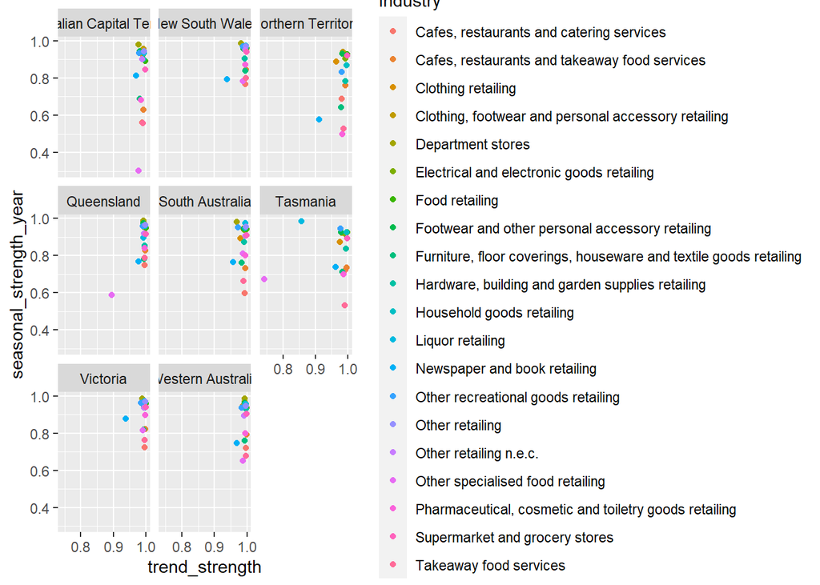

```r
aus_retail %>%
  features(Turnover, feat_stl) %>%
  ggplot(aes(x = trend_strength, y = seasonal_strength_year,
             col = Industry)) +
  geom_point() +
  facet_wrap(vars(State))
```

The above graphic shows that for all of the different states and industries there is generally a strong trend.There is a number of different industries so it is a little hard to tell which industries are showing the greatest seasonal trends, but it would appear to be the other retailing services.

```r
aus_retail %>% features(Turnover, feat_spectral) %>%
  arrange(spectral_entropy) %>%
  head(5)
```

```
## # A tibble: 5 x 3
##   State              Industry                                   spectral_entropy
##   <chr>              <chr>                                                 <dbl>
## 1 Queensland         Other retailing n.e.c.                               0.0557
## 2 Northern Territory Footwear and other personal accessory ret~           0.0724
## 3 Western Australia  Liquor retailing                                     0.0800
## 4 Northern Territory Food retailing                                       0.0817
## 5 Northern Territory Supermarket and grocery stores                       0.0831
```

Another statistic we can attempt to select is the spectral entropy, a measure of how easy a series is to forecast. Here we will just have a look at the lowest spectral entropy value. We can see hear that Queensland other retailing n. e c. has a spectral entropy closest to 0, hence it should be the easiest to forecast. This suggests that it has a high amount seasonality as well as a strong trend.

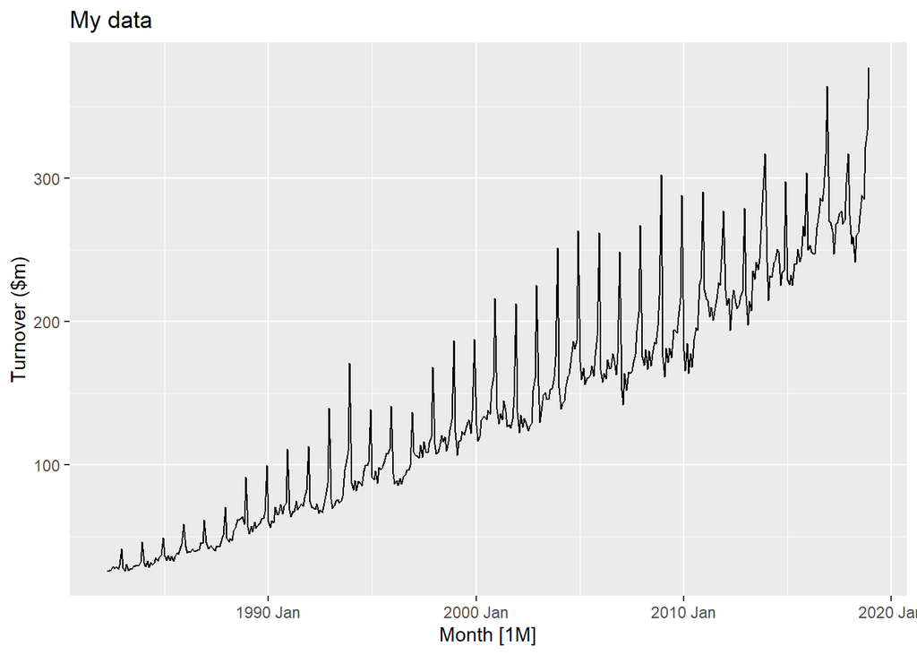

```r
set.seed(31479839)
myseries <- aus_retail %>%
  # Remove discontinued series
  filter(!(`Series ID` %in% c("A3349561R","A3349883F","A3349499L","A3349902A",
                        "A3349588R","A3349763L","A3349372C","A3349450X",
                        "A3349679W","A3349378T","A3349767W","A3349451A"))) %>%
  # Select a series at random
  filter(`Series ID` == sample(`Series ID`,1))

myseries %>% autoplot(Turnover) + labs(y = "Turnover ($m)", title = "My data")
```

## Transformation and Differencing

In general there could be a few issues with this data that may require a transformation. One could be the impact of inflation, the next could be the impact of population increases. based on the data that we have this would be hard to take into account for.

One aspect of the graphic that we do notice is that the variation between seasons increases with the level of the series. One thing we can do is a box cox transformation. Below we will perform a box cox transformation to the data.

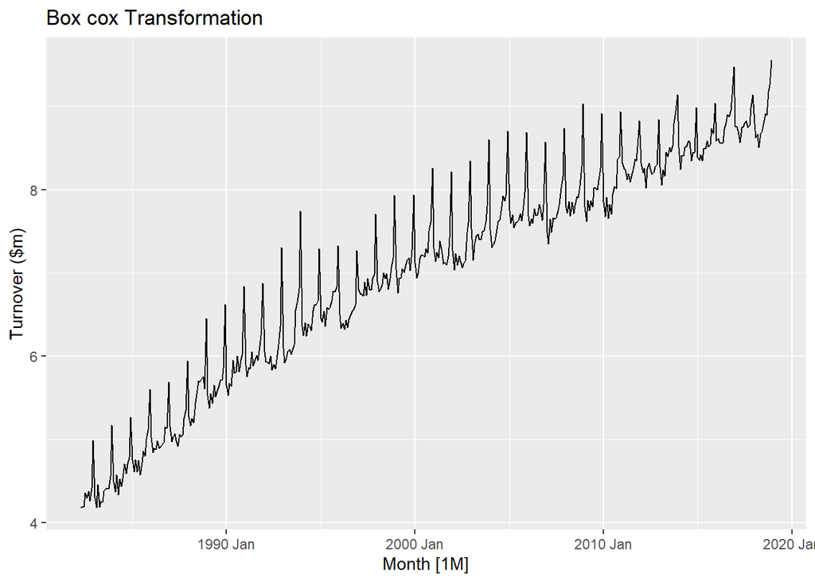

```r
lambda <- myseries %>%
  features(Turnover, features = guerrero) %>%
  pull(lambda_guerrero)


myseries %>%
  autoplot(box_cox(Turnover, lambda)) + labs(y = "Turnover ($m)", title = "Box cox Transformation")
```

We can see from the above plot that the peaks and troughs have now become somewhat more even from the box cox transformation, this will make forecasting easier and hopefully more accurate in the future.

From this the graph is still obviously none stationary, to make this graph stationary what we want to do is peform differencing.

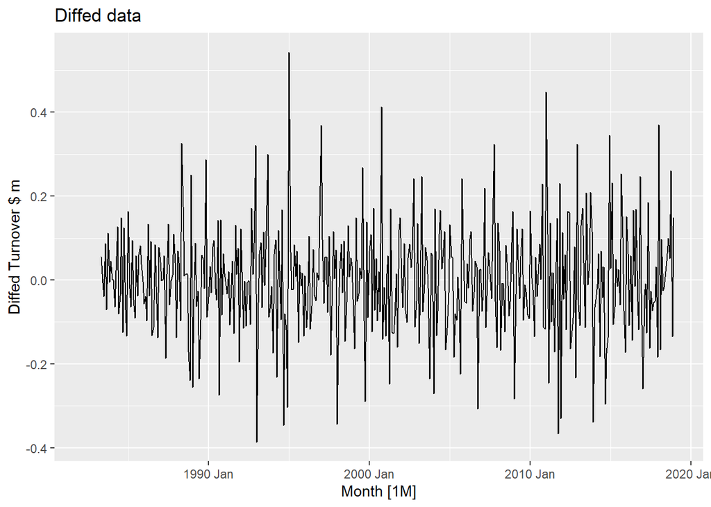

```r
myseries %>%
  mutate(diff_Turnover= difference(difference(box_cox(Turnover, lambda),12),1)) %>%
  autoplot(diff_Turnover)  + labs(y = "Diffed Turnover $ m", title = "Diffed data")
```

From above the graph does appear to lose the strong trend. Further because the data is monthly we must attempt to remove the seasonality in the data, hence we take the seasonal difference, so we will take the difference between the last value at the same time that season, at lag 12. We then perform a “first difference” on top of this that should make the graph relatively stationary. Upon visual inspection the data does appear to be stationary.

From this we can perform a unit root test. The unit root test is based under the null hypothesis that the data is stationary, and we shall try and find evidence against that.

```r
myseries %>%
  mutate(diff_Turnover= difference(difference(box_cox(Turnover, lambda),12),1)) %>% features(diff_Turnover, unitroot_kpss)
```

```
## # A tibble: 1 x 4
##   State      Industry               kpss_stat kpss_pvalue
##   <chr>      <chr>                      <dbl>       <dbl>
## 1 Queensland Other retailing n.e.c.    0.0163         0.1
```

Above we can see that there is a small test statistic of 0.0163, this implies that the p value os greater than 0.1, hence not rejecting the null hypothesis that the data is stationary.